# Phodopus molecular evolution

# Main questions

1. Does lack of recombination affect molecular evolution on the X chromosome in phodopus?

# 8 species branch rates

Goal: compare rate distributions for a small set of rodent species, including phodopus, to determine how lack of recombination on the phodopus X shapes molecular evolution on the ancestral phodopus lineage.

# Methods

## Step 0: Genome assembly and annotation (expand later)

Phodopus sungorous was de novo assembled with Dovetails, and campbelli and robovorski were assembled based on iterative mapping to the sungorus assembly. Annotation was done using the Maker pipeline (Seb’s first attempt).

We selected 5 previously sequenced rodents to estimate and compare rates of synonymous and non-synonymous substitutions with our set of newly sequenced Phodopus genomes (Table 1). The CDS sequences for these species were downloaded from Ensembl (release 100).

Selected species for comparative molecular evolution analysis

| Species | Common name | Source |
| --- | --- | --- |
| Ictidomys_tridecemlineatus | Thirteen-lined ground squirrel | Ensembl |
| Phodopus_robovorski | Roborvorski hamster | This study |
| Phodopus_campbelli | Campbell’s dwarf hamster | This study |
| Phodopus_sungorus | Djungarian hamster | This study |
| Cricetulus_griseus | Chinese hamster | Ensembl |
| Rattus_norvegicus | Brown rat | Ensembl |
| Mus_spretus | Algerian mouse | Ensembl |
| Mus_musculus | Eastern European house mouse | Ensembl |

From this set of 14,432 orthologs, 5,851 are single-copy between the 8 species selected for this analysis.

## Step 2: Align orthologs

We aligned the coding sequences from the 5,851 single-copy orthologs using a suite of programs in the MACSE software as follows:

1. Trim non-homologous regions with MACSE’s trimNonHomologousFragments program (160 genes removed at this step because at least one whole sequence was trimmed)
2. Codon aware alignments with MACSE’s alignSequences program
3. Trim gappy edges from alignment with MACSE’s trimAlignment program
4. Removed 164 alignments with premature stop codons (mostly in campbelli and robovorski)

## Step 3: Construct species and gene trees

We constructed maximum likelihood gene trees and a concatenated species tree using IQ-tree from the final 5,527 aligned coding sequences. We also used ASTRAL to construct a species tree based on quartet presence in the maximum likelihood gene trees. The concatenated ML tree and the ASTRAL tree topologies are identical (Figure 1). We used IQ-trees concordance factors to assess the confidence of the species tree as well as the consistency of the gene trees. We find that most branches in the species tree are consistently present in a high proportion of gene trees (>90% for all branches).

[figure not shown]

## Step 4: Estimation of synonymous (dS) and nonysynonymous (dN) substitution rates

We used codeml within the PAML program to estimate rates of synonymous (dS) and non-synonymous (dN) substitutions using a free-ratio model (model=1, NSsites=0) to get an estimate of rate for each branch in our phylogeny. Relationships among genes may differ amongst themselves and relative to the species relationships due to biological factors such as incomplete lineage sorting and introgression. In cases where a gene tree and the species tree disagree, inferring substitutions using the species tree (the wrong tree in this case) can lead to spurious inferences of substitutions and affect rate estimates. To mitigate this, we used the corresponding gene tree for each alignment when estimating rates. When compiling rate estimates, we only counted rates for a branch in the species tree if it existed in the gene tree (Table 2).

Number of gene trees containing branch before and after dS filtering

| Branch | Monophyletic gene trees | Genes after dS filter |
| --- | --- | --- |
| 10 | 5523 | 1172 |
| 11 | 5238 | 5146 |
| pho | 5394 | 5325 |
| 13 | 5378 | 5306 |
| 14 | 5367 | 5313 |
| mus | 5501 | 5496 |

### Filtering based on dS

As another check on alignment quality, we assessed distributions of dS along each branch and only counted genes for each branch where dS fell below 0.3. (QUESTION: should this dS filter step have a different threshold for each branch?) We also omitted genes for a branch where dN/dS was greater than 2.

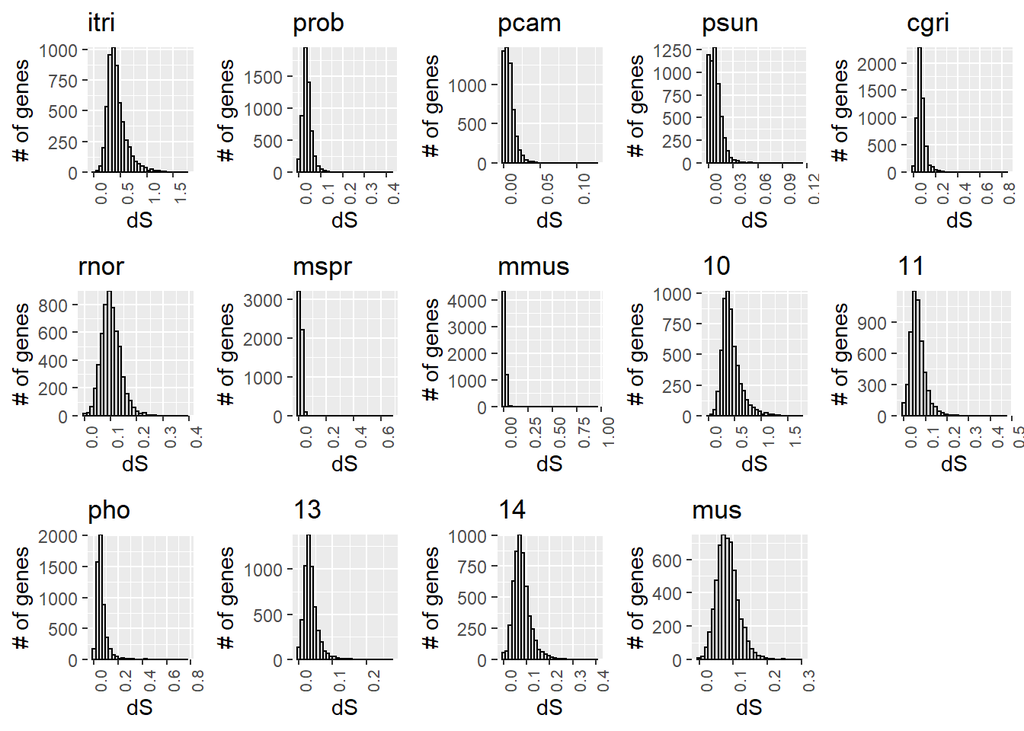

### Post filter dS distributions per branch

(QUESTION: Do we need to correct for divergence time somehow?)

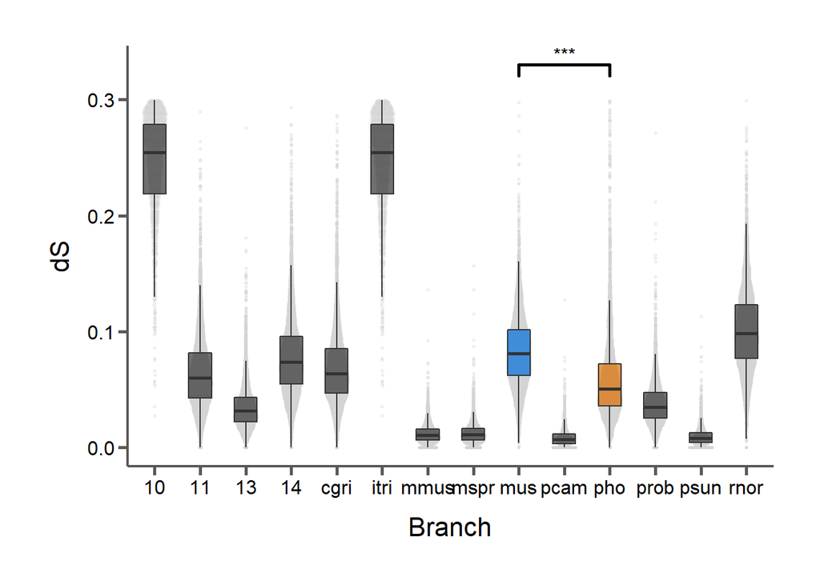

### Post filter dN distributions per branch

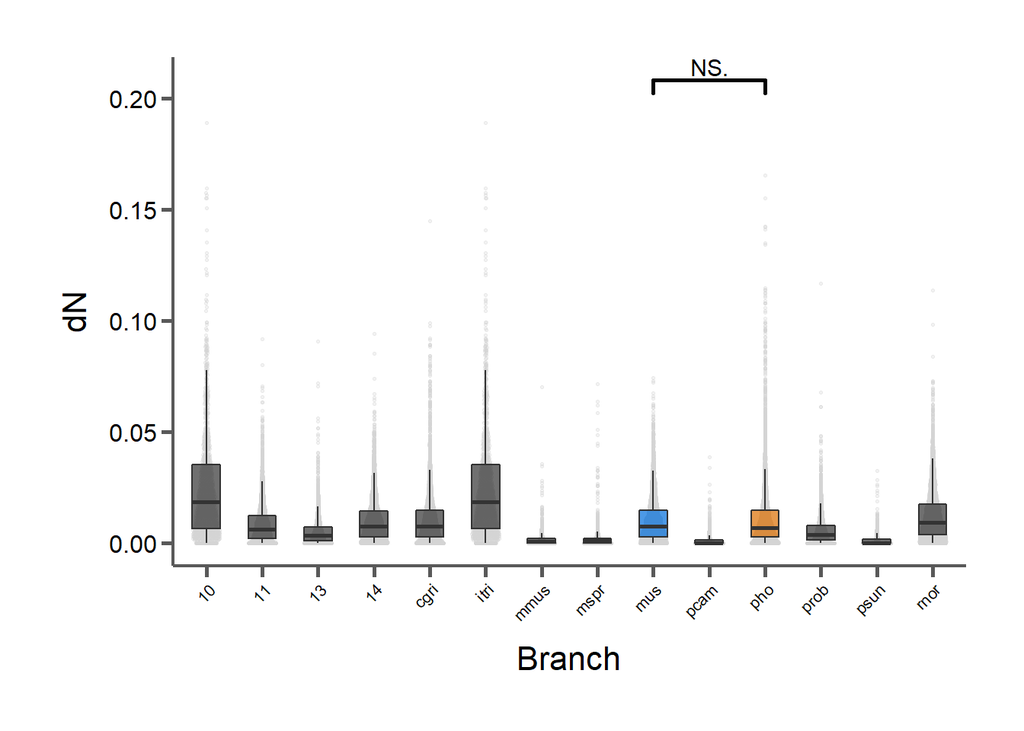

### Post filter dN/dS distributions per branch

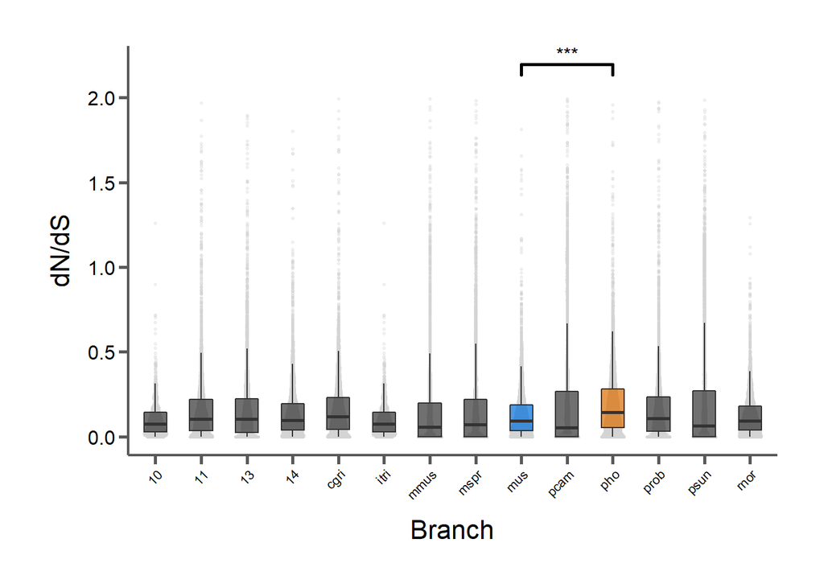

### X vs. autosome dS distributions in Mus and Phodopus

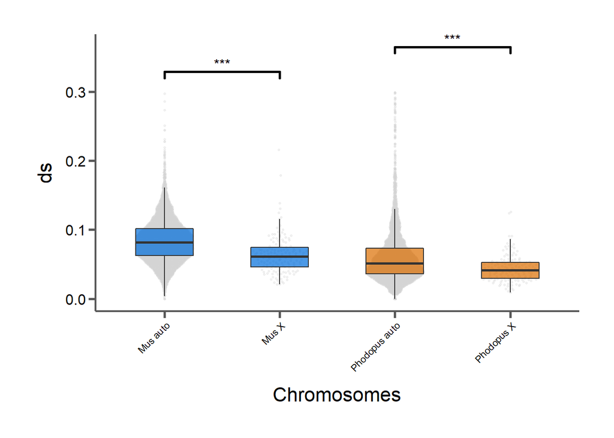

### X vs. autosome dN distributions in Mus and Phodopus

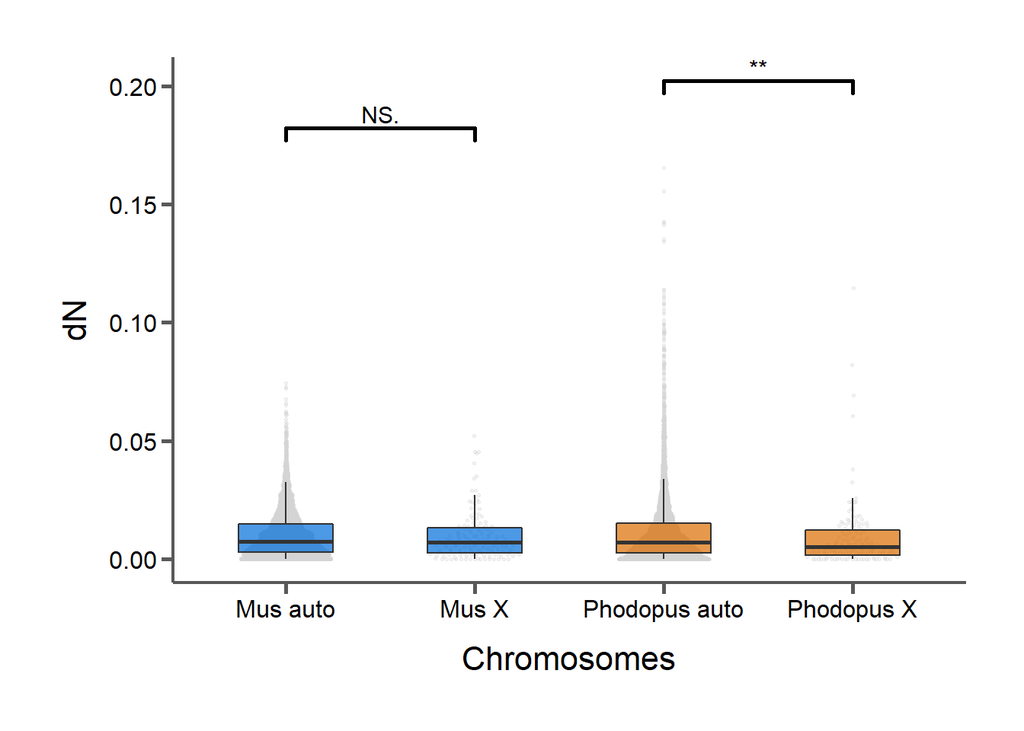

### X vs. autosome dN/dS distributions in Mus and Phodopus

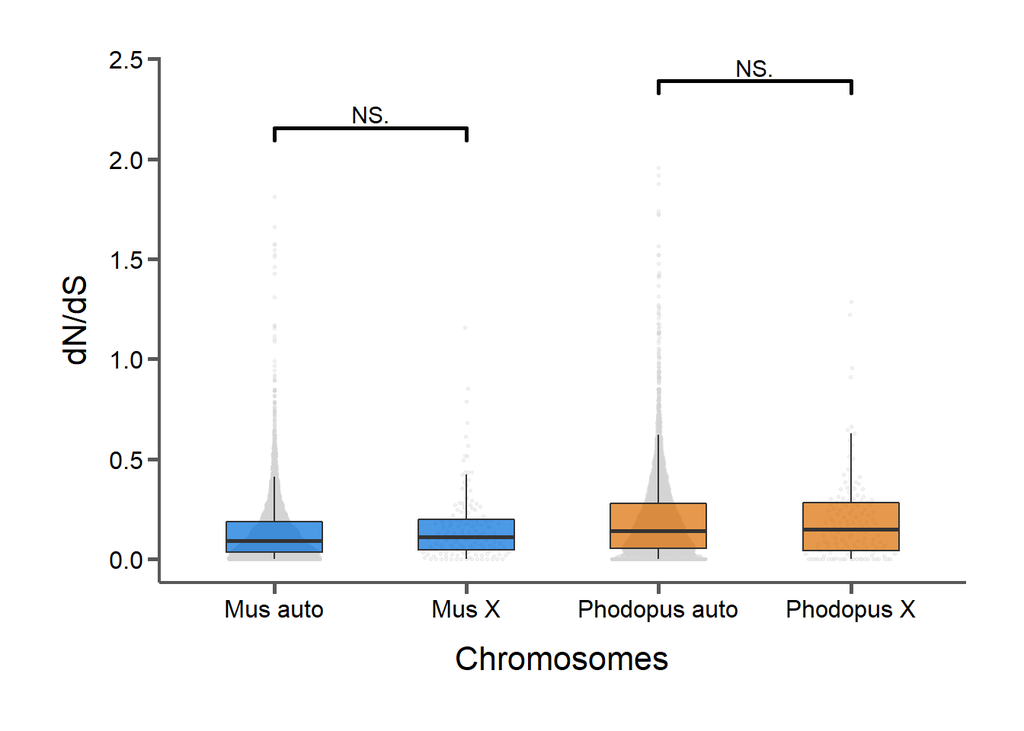

Substitution rates for Mus and Phodopus branches

| Chromosome | Number of genes | Avg. dS | Avg. dN | Avg. dN/dS |
| --- | --- | --- | --- | --- |
| Mus auto | 5352 | 0.0839927 | 0.0103321 | 0.1365710 |
| Mus X | 144 | 0.0637417 | 0.0096819 | 0.1626312 |
| Phodopus auto | 4473 | 0.0612183 | 0.0122234 | 0.1984053 |
| Phodopus X | 141 | 0.0438553 | 0.0093021 | 0.1964936 |

### X vs. autosome dS distributions in Mus and Phodopus, partitioning Phodopus X between recombining and non-recombining regions

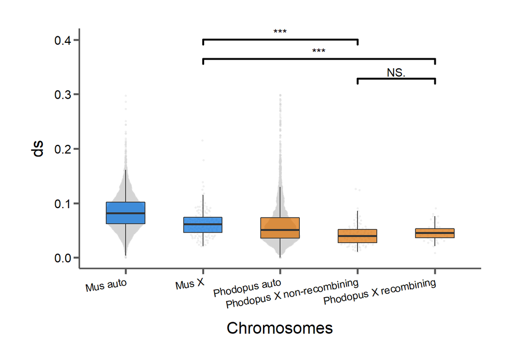

### X vs. autosome dN distributions in Mus and Phodopus, partitioning Phodopus X between recombining and non-recombining regions

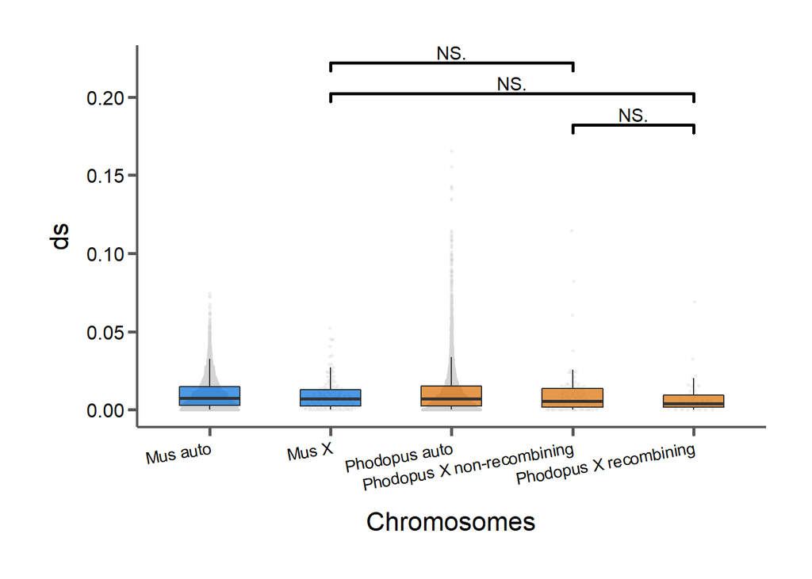

### X vs. autosome dN/dS distributions in Mus and Phodopus, partitioning Phodopus X between recombining and non-recombining regions

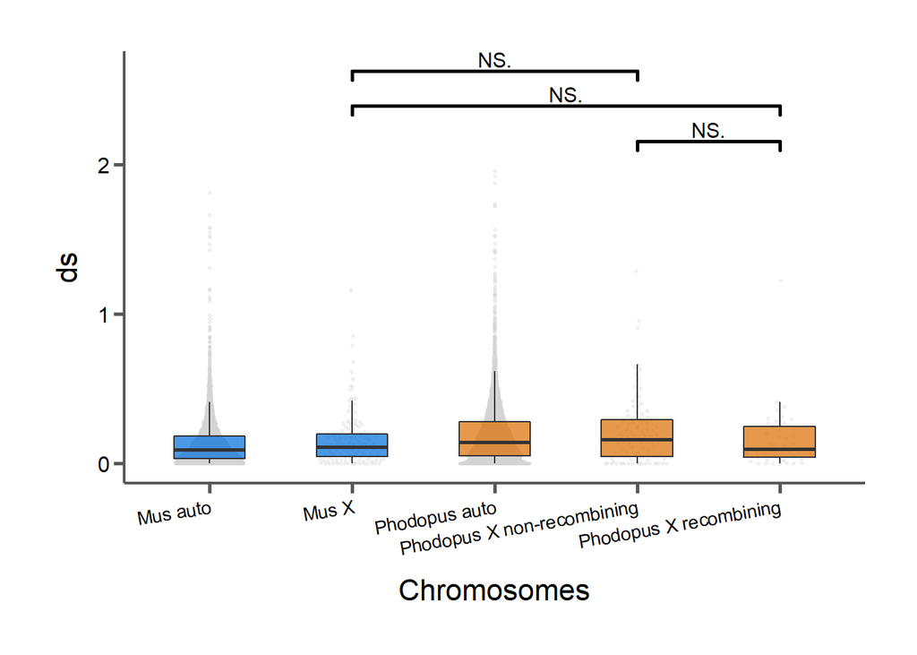

Substitution rates for Mus and Phodopus branches

| Chromosome | Number of genes | Avg. dS | Avg. dN | Avg. dN/dS |
| --- | --- | --- | --- | --- |
| Mus auto | 5352 | 0.0839927 | 0.0103321 | 0.1365710 |
| Mus X | 144 | 0.0637417 | 0.0096819 | 0.1626312 |
| Phodopus auto | 4473 | 0.0612183 | 0.0122234 | 0.1984053 |
| Phodopus X non-recombining | 96 | 0.0425031 | 0.0100156 | 0.2141042 |
| Phodopus X recombining | 45 | 0.0467400 | 0.0077800 | 0.1589244 |

# Results summary

1. High concordance among gene trees and species tree, and between species tree methods.
2. Branch leading to Phodopus has significantly lower dS and higher dN/dS than branch leading to Mus (no difference in dN).
3. Lower dS observed on X chromosome on both Mus and Phodopus branches.
4. No significant faster-X (higher dN/dS) observed on either branch (??) – though we do observe this in a pairwise comparison of musculus and spretus (not shown).
5. No difference in rates in the recombining and non-recombining regions of the X chromosome in Phodopus.

# Possible issues

1. Low number of genes on X chromosome in analysis (<200 for both Mus and Phodopus branches).